# Analyse

Baptiste Crinière-Boizet

[figure not shown]

```r
# Library
library(ggsci)
library(tidyverse)
library(ggpubr)

# Data management
data <- openxlsx::read.xlsx("/home/baptiste.criniere/Documents/PB_cell_CB/Data/Tableau data 170723.xlsx")
names(data) <- c("ID", "Group", "Cell_count", "Cell_tot", "Astros", "Area", "Prop", "Density")
data <- data %>%
  dplyr::mutate(ID = ID %>% factor) %>%
  dplyr::mutate(Group = Group %>% factor)
```

# Raw data analysis

## Bi-variate analysis

### Correlation between the total number of cell and the density

This first graph suggests a correlation between cell number and cell density. This correlation is 0.37 and is significantly different from zero (pvalue=0.017).

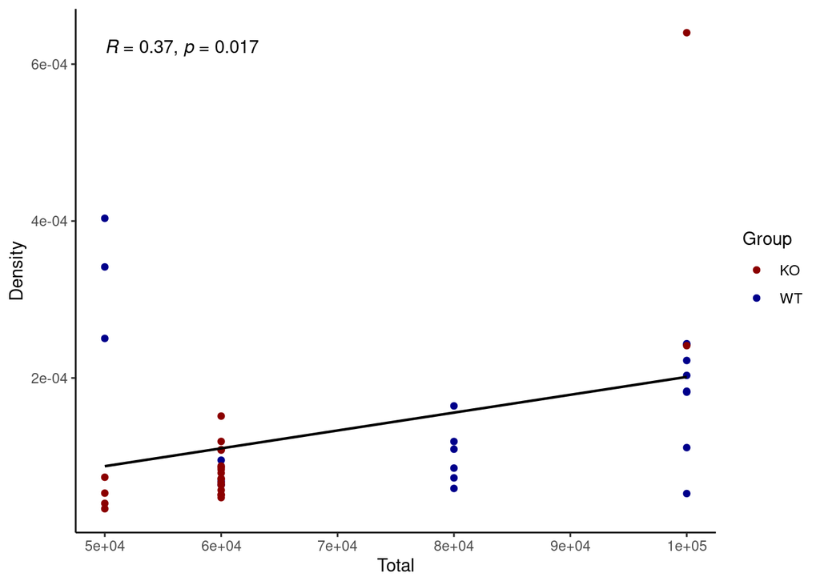

```r
data %>%
  ggplot(aes(x = Cell_tot, y = Density))+
  geom_point(aes(color = Group), size = 1.5)+
  geom_smooth(method = "lm", se = F, color = "black", size = 0.75)+
  theme_classic()+
  stat_cor()+
  scale_color_manual(values = c("darkred", "darkblue"))+
  labs(x = "Total")
```

### Boxplot & wilcoxon test

The boxplots show a significant trend for a difference in proportions between the two cell lines regardless of the total number of cells (Wilcoxon rank-sum test, pvalue=0.0054). The average density in the KO group is 1.1e-4 and in the WT group 1.6e-4.

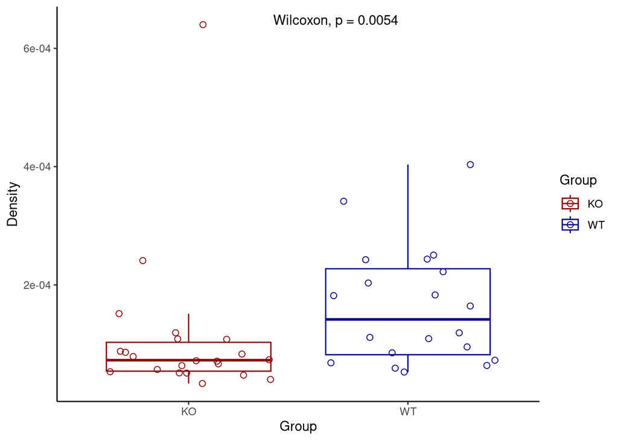

```r
data %>%
  ggplot(aes(x = Group, y = Density))+
  geom_boxplot(aes(color = Group), outlier.shape = NA)+
  geom_jitter(aes(color = Group), size = 2, shape = 1)+
  stat_compare_means(label.x = 1.5)+
  theme_classic()+
  scale_color_manual(values = c("darkred", "darkblue"))
```

## Linear model

Testing the effects of the cell Line and the total number of cells based on a linear regression model fitted to the proportion values. Significant interaction between Group and Total (p=6e-06) suggests that the group difference varies with the total number of cells.

### Data visualisation

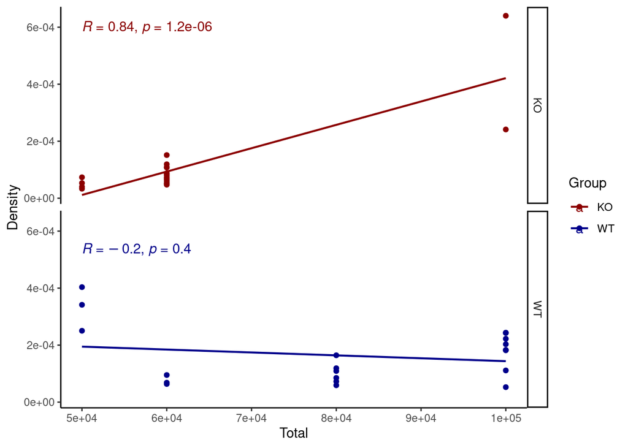

```r
data %>%
  ggplot(aes(x = Cell_tot, y = Density, color = Group))+
  geom_point()+
  geom_smooth(method = "lm", se = FALSE, size = 0.75)+
  stat_cor()+
  facet_grid(rows = vars(Group))+
  theme_classic()+
  scale_color_manual(values = c("darkred", "darkblue"))+
  labs(x = "Total")
```

### Model

```r
model <- lm(Density ~ Cell_tot*Group, data = data)
car::Anova(model)
```

```
## Anova Table (Type II tests)
##
## Response: Density
##                    Sum Sq Df F value    Pr(>F)
## Cell_tot       4.4260e-08  1  6.0399   0.01866 *
## Group          2.2930e-09  1  0.3129   0.57921
## Cell_tot:Group 2.0012e-07  1 27.3084 6.546e-06 ***
## Residuals      2.7847e-07 38
## ---
## Signif. codes:  0 '***' 0.001 '**' 0.01 '*' 0.05 '.' 0.1 ' ' 1
```

### Checking model assumptions

Below is a quality control of the fitted LM indicating a poor adjustment of the data (important deviation from a normal distribution).

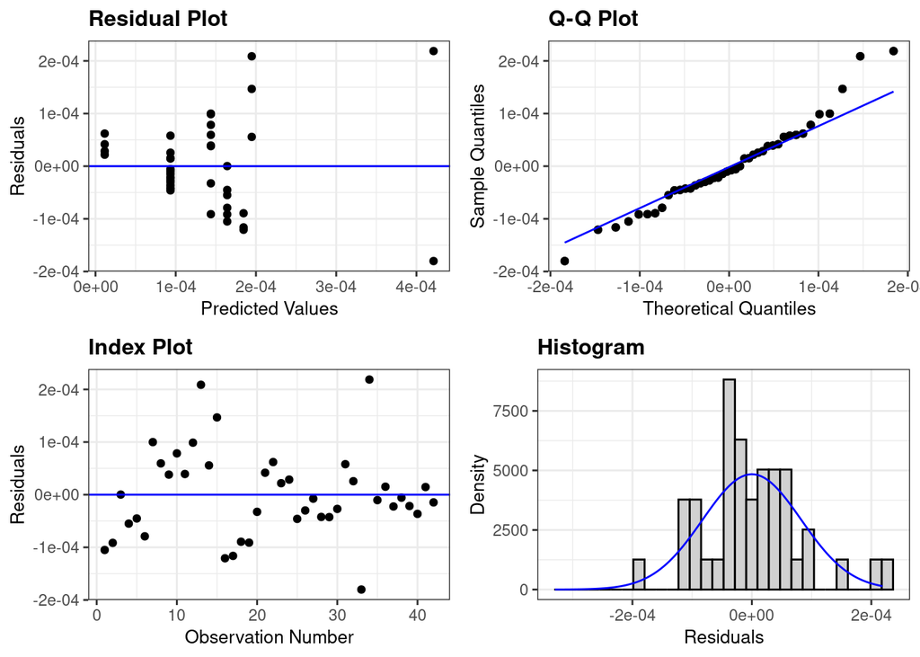

```r
ggResidpanel::resid_panel(model)
```

## Linear model with log transformation

The log is usually used to symmetrize a skewed distribution and reduce the weight of extreme points. Considering a log transformation leads to the same conclusion with the LM, but with a fit that looks better visually.

### Data visualisation

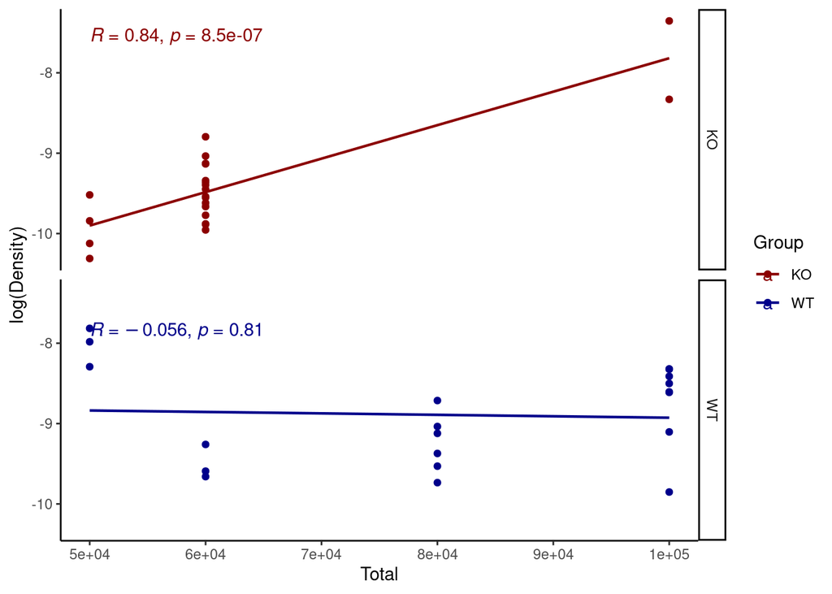

```r
data %>%
  ggplot(aes(x = Cell_tot, y = log(Density), color = Group))+
  geom_point()+
  geom_smooth(method = "lm", se = FALSE, size = 0.75)+
  stat_cor()+
  facet_grid(rows = vars(Group))+
  theme_classic()+
  scale_color_manual(values = c("darkred", "darkblue"))+
  labs(x = "Total")
```

### Model

```r
model <- lm(log(Density) ~ Cell_tot*Group, data = data)
car::Anova(model)
```

```
## Anova Table (Type II tests)
##
## Response: log(Density)
##                Sum Sq Df F value    Pr(>F)
## Cell_tot       1.6946  1  6.6753 0.0137466 *
## Group          0.6125  1  2.4129 0.1286321
## Cell_tot:Group 4.4472  1 17.5186 0.0001622 ***
## Residuals      9.6465 38
## ---
## Signif. codes:  0 '***' 0.001 '**' 0.01 '*' 0.05 '.' 0.1 ' ' 1
```

### Checking model assumptions

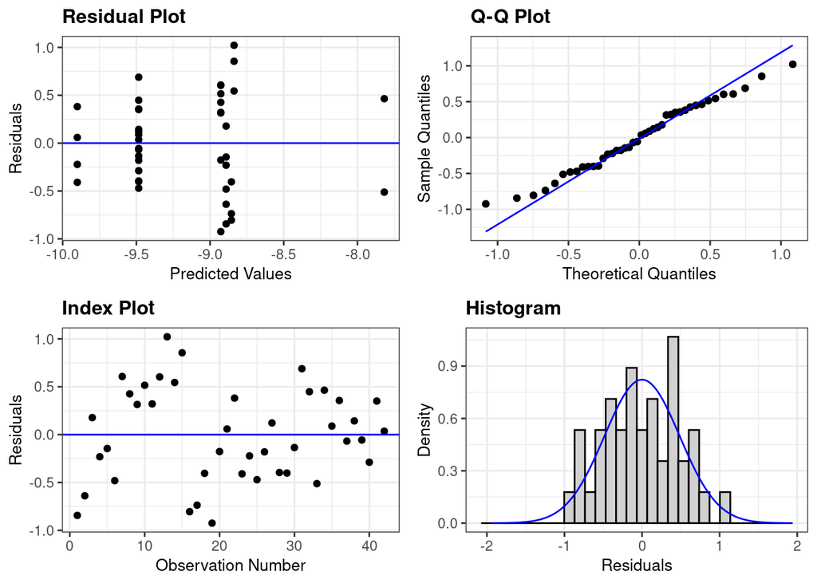

```r
ggResidpanel::resid_panel(model)
```

# Partial data

The following analysis excludes 5 values from 3 samples “WT3.2”, “K-8.1MBPQK11” and “K-8.1MBPQK12”.

```r
data_bis <- data %>%
  dplyr::filter(!(ID %in% c("WT3.2", "K-8.1MBPQK11", "K-8.1MBPQK12")))
```

## Bi-variate analysis

### Boxplot & wilcoxon test

The boxplots show a significant trend for a difference in proportions between the two cell lines regardless of the total number of cells (Wilcoxon rank-sum test, pvalue=0.0035).

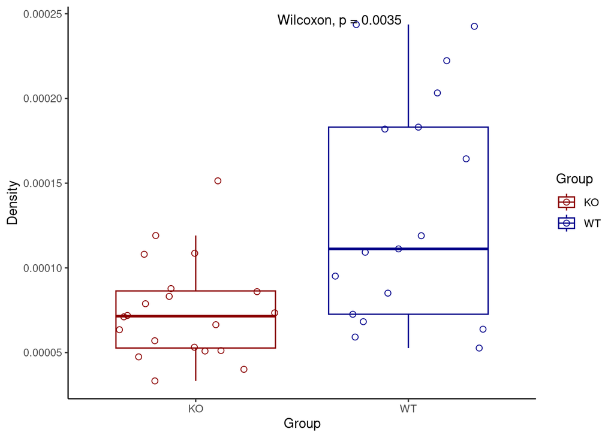

```r
data_bis %>%
  ggplot(aes(x = Group, y = Density))+
  geom_boxplot(aes(color = Group), outlier.shape = NA)+
  geom_jitter(aes(color = Group), size = 2, shape = 1)+
  stat_compare_means(label.x = 1.5)+
  theme_classic()+
  scale_color_manual(values = c("darkred", "darkblue"))
```

## Linear model

In this new linear model, we no longer find an interaction effect (nor a group effect), only an effect of the total number of cells on density. Which seems to be the same for both groups.

### Data visualisation

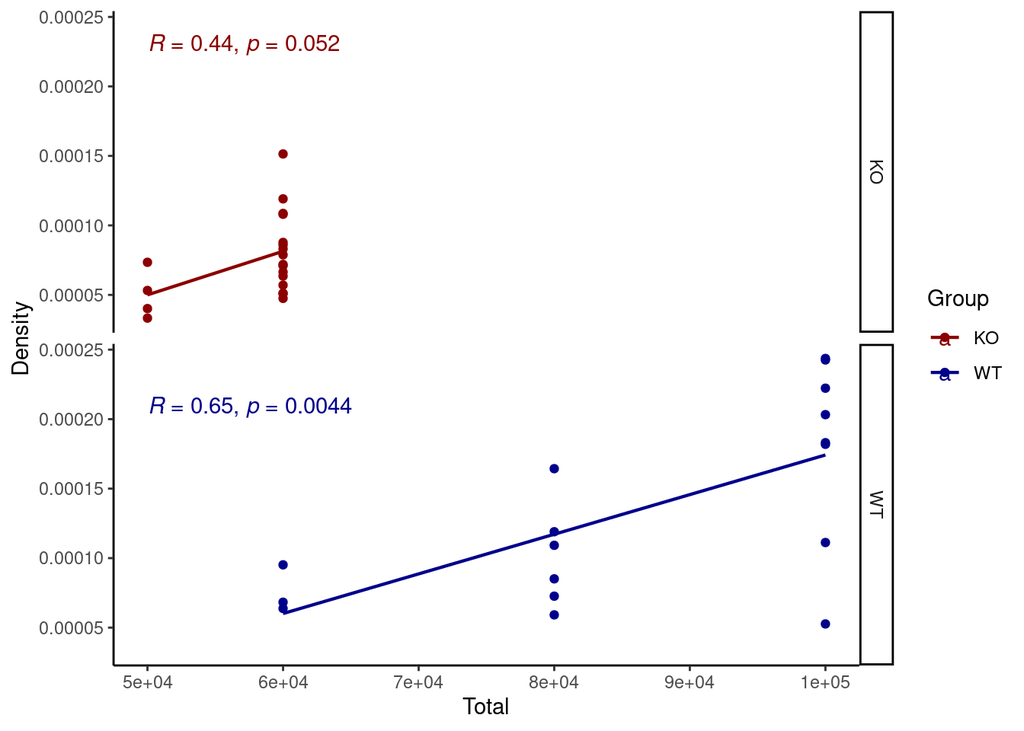

```r
data_bis %>%
  ggplot(aes(x = Cell_tot, y = Density, color = Group))+
  geom_point()+
  geom_smooth(method = "lm", se = FALSE, size = 0.75)+
  stat_cor()+
  facet_grid(rows = vars(Group))+
  theme_classic()+
  scale_color_manual(values = c("darkred", "darkblue"))+
  labs(x = "Total")
```

### Model

```r
model <- lm(Density ~ Cell_tot*Group, data = data_bis)
car::Anova(model)
```

```
## Anova Table (Type II tests)
##
## Response: Density
##                    Sum Sq Df F value    Pr(>F)
## Cell_tot       3.4129e-08  1 20.6246 7.076e-05 ***
## Group          1.5270e-09  1  0.9231    0.3437
## Cell_tot:Group 2.4000e-11  1  0.0146    0.9047
## Residuals      5.4608e-08 33
## ---
## Signif. codes:  0 '***' 0.001 '**' 0.01 '*' 0.05 '.' 0.1 ' ' 1
```

### Checking model assumptions

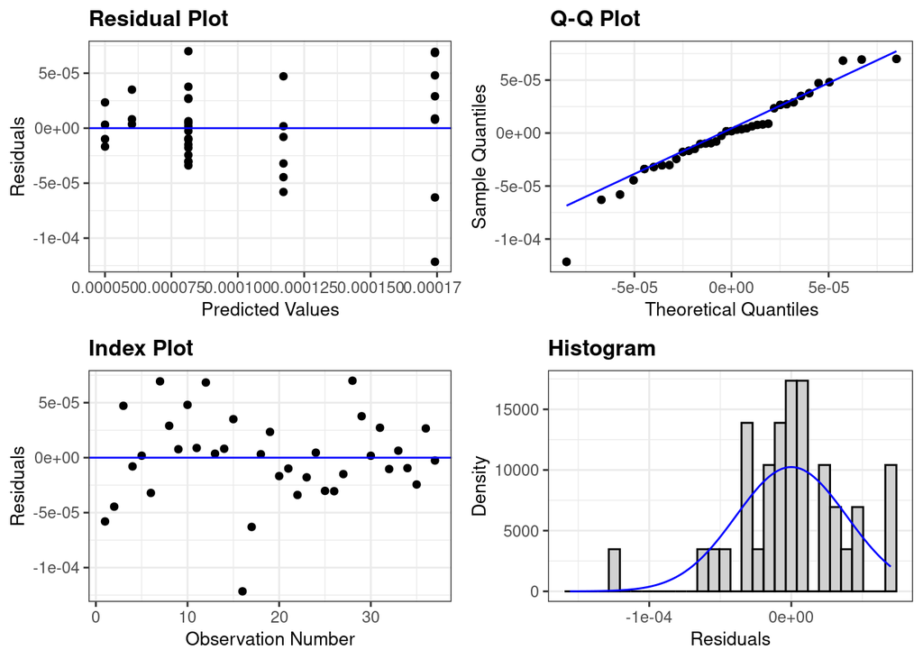

```r
ggResidpanel::resid_panel(model)
```